# My Project: Student Performance Classification - Predicting Academic Success

## Introducing the problem:

So for this project, I'm switching gears from regression to classification. Instead of predicting exact exam scores like in Project 1, I want to see if I can predict which performance category a student will fall into - basically, are they going to struggle, do okay, or excel?

This is useful because teachers and schools often think about students in these broad categories anyway. For example, they want to know which kids might need extra help, which ones are on track, and which ones might be ready for advanced work.

### Research Questions:

1. **Can I actually predict performance categories accurately?** Like, how well can I tell if a student will be low, medium, or high performing?
2. **What factors matter most for classification?** Are the same things that predicted exact scores also the best for predicting categories?
3. **Do different algorithms work better for this?** Maybe some machine learning methods are better at classification than others.
4. **How do socioeconomic factors show up in categories?** Do we see clear patterns where certain backgrounds lead to certain performance levels?
5. **Can I identify at-risk students early?** This could be really valuable for getting help to students who need it.

I'm using the same dataset as Project 1, but instead of predicting the exact exam score, I'm going to group students into Low (55-65), Medium (66-75), and High (76+) performance categories. This should make the predictions more actionable for educators.

## The data I'm working with

I'm using the **StudentPerformanceFactors.csv** dataset which has 6,607 student records. It's got features such as study habits, family background, school environment, personal factors, and support systems.

The key difference this time is that instead of using the exact exam score as my target, I'm going to convert it into categories:

- **Low Performance**: 55-65 (students who might need special attention)
- **Medium Performance**: 66-75 (students that require support to get on track)
- **High Performance**: 76+ (students excelling)

This should make the predictions more useful for teachers who think in terms of "this student needs support" vs "this student is doing fine" vs "this student is ready for challenges."

The dataset has all the same features as before:

- Study habits (hours studied, previous scores, attendance)
- Family stuff (parental involvement, education, income)
- School environment (public/private, teacher quality, resources)
- Personal factors (motivation, sleep, physical activity, gender)
- Support systems (tutoring, internet access, extracurriculars)
- Social factors (peer influence, distance from home)

In this project, I am curious to see if the same factors that predicted exact scores will also be good at predicting these broader categories.

```python
!pip3 install pandas matplotlib numpy seaborn scikit-learn
```

[output not shown]

```python
# Import necessary libraries
import pandas as pd
import numpy as np
import matplotlib.pyplot as plt
import seaborn as sns
from sklearn.model_selection import train_test_split, cross_val_score, GridSearchCV
from sklearn.preprocessing import LabelEncoder, StandardScaler, OneHotEncoder
from sklearn.ensemble import RandomForestClassifier, GradientBoostingClassifier
from sklearn.linear_model import LogisticRegression
from sklearn.svm import SVC
from sklearn.tree import DecisionTreeClassifier
from sklearn.metrics import classification_report, confusion_matrix, accuracy_score, precision_score, recall_score, f1_score
from sklearn.compose import ColumnTransformer
from sklearn.pipeline import Pipeline
import warnings
warnings.filterwarnings('ignore')

# Set style for better-looking plots
plt.style.use('default')
plt.rcParams['figure.figsize'] = (12, 8)
plt.rcParams['font.size'] = 10
sns.set_palette("husl")

# Display options for pandas
pd.set_option('display.max_columns', None)
pd.set_option('display.width', None)

print("Libraries imported successfully!")
```

```
Libraries imported successfully!
```

```python
# Load the dataset
df = pd.read_csv('StudentPerformanceFactors.csv')

print("Dataset Shape:", df.shape)
print("\nFirst few rows:")
df.head()
```

```
Dataset Shape: (6607, 20)

First few rows:
```

|  | Hours_Studied | Attendance | Parental_Involvement | Access_to_Resources | Extracurricular_Activities | Sleep_Hours | Previous_Scores | Motivation_Level | Internet_Access | Tutoring_Sessions | Family_Income | Teacher_Quality | School_Type | Peer_Influence | Physical_Activity | Learning_Disabilities | Parental_Education_Level | Distance_from_Home | Gender | Exam_Score |
| --- | --- | --- | --- | --- | --- | --- | --- | --- | --- | --- | --- | --- | --- | --- | --- | --- | --- | --- | --- | --- |
| 0 | 23 | 84 | Low | High | No | 7 | 73 | Low | Yes | 0 | Low | Medium | Public | Positive | 3 | No | High School | Near | Male | 67 |
| 1 | 19 | 64 | Low | Medium | No | 8 | 59 | Low | Yes | 2 | Medium | Medium | Public | Negative | 4 | No | College | Moderate | Female | 61 |
| 2 | 24 | 98 | Medium | Medium | Yes | 7 | 91 | Medium | Yes | 2 | Medium | Medium | Public | Neutral | 4 | No | Postgraduate | Near | Male | 74 |
| 3 | 29 | 89 | Low | Medium | Yes | 8 | 98 | Medium | Yes | 1 | Medium | Medium | Public | Negative | 4 | No | High School | Moderate | Male | 71 |
| 4 | 19 | 92 | Medium | Medium | Yes | 6 | 65 | Medium | Yes | 3 | Medium | High | Public | Neutral | 4 | No | College | Near | Female | 70 |

```python
# Basic information about the dataset
print("Dataset Info:")
print(df.info())
print("\nMissing values:")
print(df.isnull().sum())
print("\nTarget variable (Exam_Score) statistics:")
print(df['Exam_Score'].describe())
```

```
Dataset Info:
<class 'pandas.core.frame.DataFrame'>
RangeIndex: 6607 entries, 0 to 6606
Data columns (total 20 columns):
 #   Column                      Non-Null Count  Dtype
---  ------                      --------------  -----
 0   Hours_Studied               6607 non-null   int64
 1   Attendance                  6607 non-null   int64
 2   Parental_Involvement        6607 non-null   object
 3   Access_to_Resources         6607 non-null   object
 4   Extracurricular_Activities  6607 non-null   object
 5   Sleep_Hours                 6607 non-null   int64
 6   Previous_Scores             6607 non-null   int64
 7   Motivation_Level            6607 non-null   object
 8   Internet_Access             6607 non-null   object
 9   Tutoring_Sessions           6607 non-null   int64
 10  Family_Income               6607 non-null   object
 11  Teacher_Quality             6529 non-null   object
 12  School_Type                 6607 non-null   object
 13  Peer_Influence              6607 non-null   object
 14  Physical_Activity           6607 non-null   int64
 15  Learning_Disabilities       6607 non-null   object
 16  Parental_Education_Level    6517 non-null   object
 17  Distance_from_Home          6540 non-null   object
 18  Gender                      6607 non-null   object
 19  Exam_Score                  6607 non-null   int64
dtypes: int64(7), object(13)
memory usage: 1.0+ MB
None

Missing values:
Hours_Studied                  0
Attendance                     0
Parental_Involvement           0
Access_to_Resources            0
Extracurricular_Activities     0
Sleep_Hours                    0
Previous_Scores                0
Motivation_Level               0
Internet_Access                0
```

[output cut: 8 more lines]

```
Distance_from_Home            67
Gender                         0
Exam_Score                     0
dtype: int64

Target variable (Exam_Score) statistics:
count    6607.000000
mean       67.235659
std         3.890456
min        55.000000
25%        65.000000
50%        67.000000
75%        69.000000
max       101.000000
Name: Exam_Score, dtype: float64
```

## Preprocessing the data

### Creating my classification target

So the first thing I need to do is convert the continuous exam scores into categories. I decided to use these cutoffs:

- **Low Performance**: 55-65 (students who might need extra help)
- **Medium Performance**: 66-75 (students doing okay)
- **High Performance**: 76+ (students excelling)

I picked these ranges because they seem to match how teachers actually think about student performance. Like, 55-65 is definitely in the "needs support" range, 66-75 is "doing fine," and 76+ is "really doing well."

This should make the predictions more actionable, so I can say something along the lines of "this student will likely be in the medium performance category."

```
Performance Level Distribution:
Performance_Level
Medium    4400
Low       2131
High        76
Name: count, dtype: int64

Performance Level Proportions:
Performance_Level
Medium    0.665960
Low       0.322537
High      0.011503
Name: proportion, dtype: float64
```

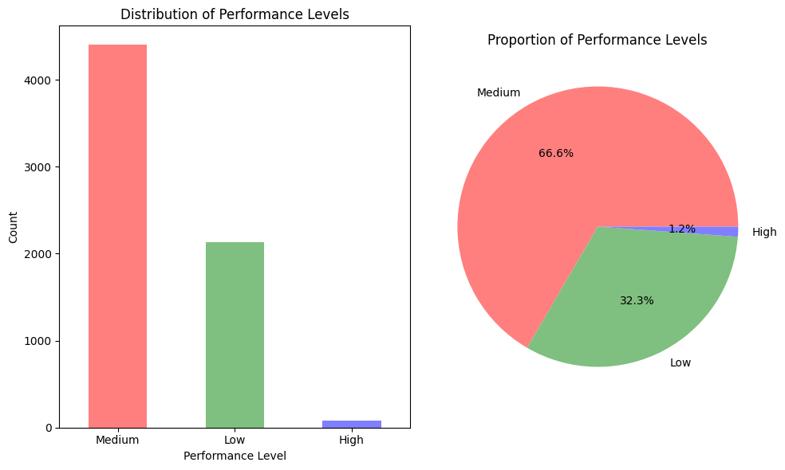

```python
# Create performance categories
def categorize_performance(score):
    if score <= 65:
        return 'Low'
    elif score <= 75:
        return 'Medium'
    else:
        return 'High'

# Apply categorization
df['Performance_Level'] = df['Exam_Score'].apply(categorize_performance)

# Check the distribution of performance levels
print("Performance Level Distribution:")
print(df['Performance_Level'].value_counts())
print("\nPerformance Level Proportions:")
print(df['Performance_Level'].value_counts(normalize=True))

# Visualize the distribution
plt.figure(figsize=(10, 6))
plt.subplot(1, 2, 1)
df['Performance_Level'].value_counts().plot(kind='bar', color=['#ff7f7f', '#7fbf7f', '#7f7fff'])
plt.title('Distribution of Performance Levels')
plt.xlabel('Performance Level')
plt.ylabel('Count')
plt.xticks(rotation=0)

plt.subplot(1, 2, 2)
df['Performance_Level'].value_counts(normalize=True).plot(kind='pie', autopct='%1.1f%%',
                                                          colors=['#ff7f7f', '#7fbf7f', '#7f7fff'])
plt.title('Proportion of Performance Levels')
plt.ylabel('')

plt.tight_layout()
plt.show()
```

```python
# Handle missing values
print("Missing values before preprocessing:")
print(df.isnull().sum())

# Fill missing values with appropriate strategies
# For categorical variables, use mode (most frequent value)
df['Teacher_Quality'].fillna(df['Teacher_Quality'].mode()[0], inplace=True)
df['Parental_Education_Level'].fillna(df['Parental_Education_Level'].mode()[0], inplace=True)
df['Distance_from_Home'].fillna(df['Distance_from_Home'].mode()[0], inplace=True)

print("\nMissing values after preprocessing:")
print(df.isnull().sum())

# Check unique values in categorical columns
print("\nUnique values in categorical columns:")
categorical_cols = df.select_dtypes(include=['object']).columns
for col in categorical_cols:
    if col != 'Performance_Level':  # Exclude our target variable
        print(f'{col}: {df[col].unique()}')
```

```
Missing values before preprocessing:
Hours_Studied                  0
Attendance                     0
Parental_Involvement           0
Access_to_Resources            0
Extracurricular_Activities     0
Sleep_Hours                    0
Previous_Scores                0
Motivation_Level               0
Internet_Access                0
Tutoring_Sessions              0
Family_Income                  0
Teacher_Quality               78
School_Type                    0
Peer_Influence                 0
Physical_Activity              0
Learning_Disabilities          0
Parental_Education_Level      90
Distance_from_Home            67
Gender                         0
Exam_Score                     0
Performance_Level              0
dtype: int64

Missing values after preprocessing:
Hours_Studied                 0
Attendance                    0
Parental_Involvement          0
Access_to_Resources           0
Extracurricular_Activities    0
Sleep_Hours                   0
Previous_Scores               0
Motivation_Level              0
Internet_Access               0
Tutoring_Sessions             0
Family_Income                 0
Teacher_Quality               0
School_Type                   0
Peer_Influence                0
Physical_Activity             0
Learning_Disabilities         0
Parental_Education_Level      0
Distance_from_Home            0
Gender                        0
Exam_Score                    0
Performance_Level             0
dtype: int64

Unique values in categorical columns:
Parental_Involvement: ['Low' 'Medium' 'High']
Access_to_Resources: ['High' 'Medium' 'Low']
Extracurricular_Activities: ['No' 'Yes']
Motivation_Level: ['Low' 'Medium' 'High']
Internet_Access: ['Yes' 'No']
Family_Income: ['Low' 'Medium' 'High']
Teacher_Quality: ['Medium' 'High' 'Low']
School_Type: ['Public' 'Private']
Peer_Influence: ['Positive' 'Negative' 'Neutral']
Learning_Disabilities: ['No' 'Yes']
Parental_Education_Level: ['High School' 'College' 'Postgraduate']
Distance_from_Home: ['Near' 'Moderate' 'Far']
Gender: ['Male' 'Female']
```

```python
# Prepare features and target
# Remove the original Exam_Score as we're using Performance_Level as target
X = df.drop(['Exam_Score', 'Performance_Level'], axis=1)
y = df['Performance_Level']

# Identify numerical and categorical columns
numerical_cols = X.select_dtypes(include=[np.number]).columns.tolist()
categorical_cols = X.select_dtypes(include=['object']).columns.tolist()

print("Numerical columns:", numerical_cols)
print("Categorical columns:", categorical_cols)

# Create preprocessing pipeline
# For categorical variables, use OneHotEncoder
# For numerical variables, use StandardScaler
preprocessor = ColumnTransformer(
    transformers=[
        ('num', StandardScaler(), numerical_cols),
        ('cat', OneHotEncoder(drop='first', sparse_output=False), categorical_cols)
    ]
)

# Apply preprocessing
X_processed = preprocessor.fit_transform(X)

# Get feature names after preprocessing
feature_names = (numerical_cols +
                list(preprocessor.named_transformers_['cat'].get_feature_names_out(categorical_cols)))

print(f"\nProcessed feature matrix shape: {X_processed.shape}")
print(f"Number of features after preprocessing: {len(feature_names)}")

# Split the data
X_train, X_test, y_train, y_test = train_test_split(X_processed, y, test_size=0.2, random_state=42, stratify=y)

print(f"\nTraining set size: {X_train.shape[0]}")
print(f"Test set size: {X_test.shape[0]}")
print(f"Training set target distribution:")
print(y_train.value_counts(normalize=True))
```

```
Numerical columns: ['Hours_Studied', 'Attendance', 'Sleep_Hours', 'Previous_Scores', 'Tutoring_Sessions', 'Physical_Activity']
Categorical columns: ['Parental_Involvement', 'Access_to_Resources', 'Extracurricular_Activities', 'Motivation_Level', 'Internet_Access', 'Family_Income', 'Teacher_Quality', 'School_Type', 'Peer_Influence', 'Learning_Disabilities', 'Parental_Education_Level', 'Distance_from_Home', 'Gender']

Processed feature matrix shape: (6607, 27)
Number of features after preprocessing: 27

Training set size: 5285
Test set size: 1322
Training set target distribution:
Performance_Level
Medium    0.665847
Low       0.322611
High      0.011542
Name: proportion, dtype: float64
```

## Understanding the data

Before I start building classification models, I want to explore the data and see what patterns emerge. This will help me understand which factors might be most important for predicting performance categories.

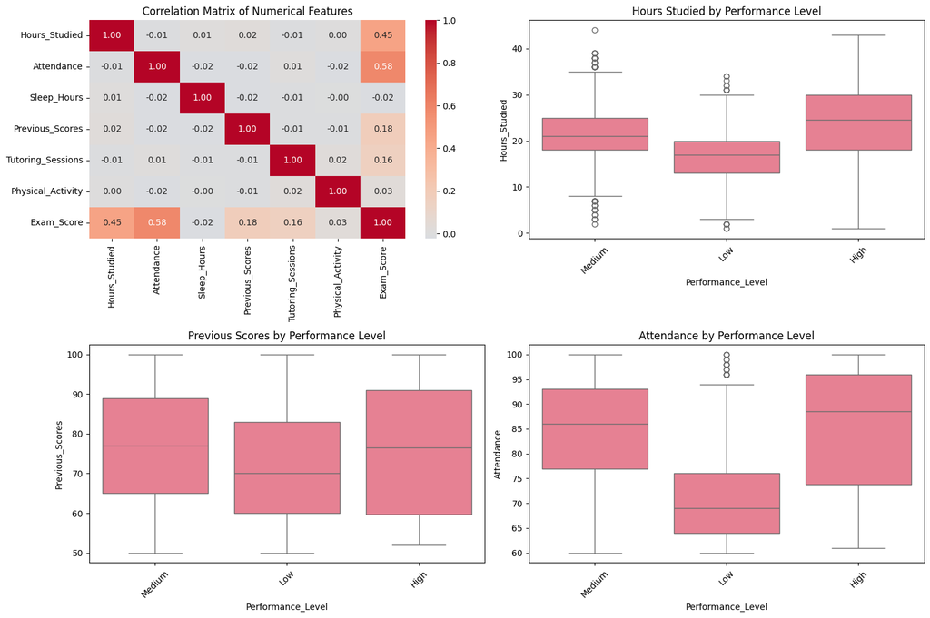

```python
# Correlation analysis for numerical features
plt.figure(figsize=(15, 10))

# Create correlation matrix for numerical features
numerical_data = df[numerical_cols + ['Exam_Score']]
correlation_matrix = numerical_data.corr()

# Plot correlation heatmap
plt.subplot(2, 2, 1)
sns.heatmap(correlation_matrix, annot=True, cmap='coolwarm', center=0, fmt='.2f')
plt.title('Correlation Matrix of Numerical Features')

# Box plots for key numerical features by performance level
plt.subplot(2, 2, 2)
sns.boxplot(data=df, x='Performance_Level', y='Hours_Studied')
plt.title('Hours Studied by Performance Level')
plt.xticks(rotation=45)

plt.subplot(2, 2, 3)
sns.boxplot(data=df, x='Performance_Level', y='Previous_Scores')
plt.title('Previous Scores by Performance Level')
plt.xticks(rotation=45)

plt.subplot(2, 2, 4)
sns.boxplot(data=df, x='Performance_Level', y='Attendance')
plt.title('Attendance by Performance Level')
plt.xticks(rotation=45)

plt.tight_layout()
plt.show()
```

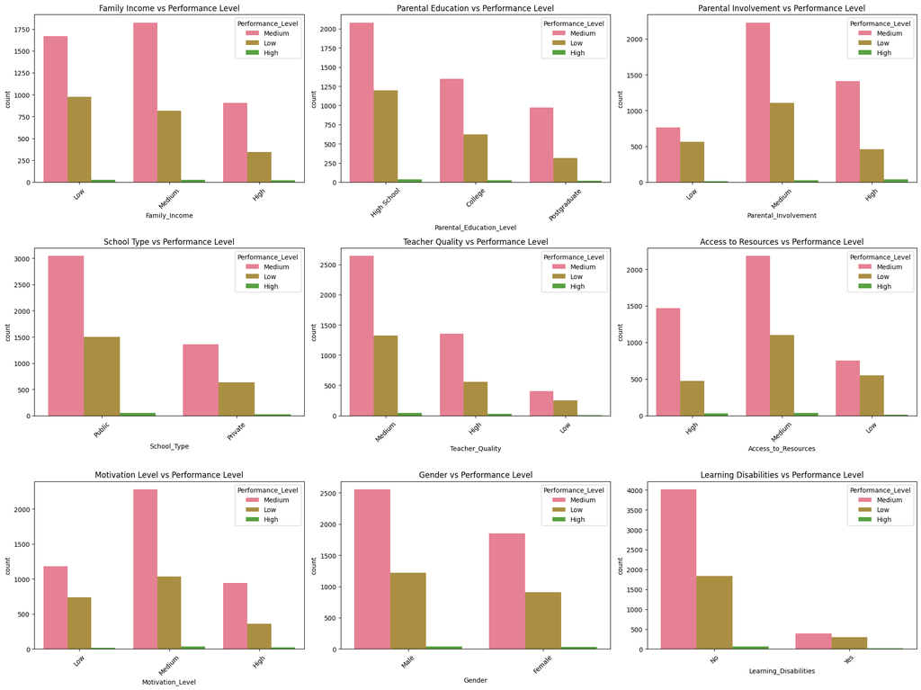

```python
# Analyze categorical features
plt.figure(figsize=(20, 15))

# Family and socioeconomic factors
plt.subplot(3, 3, 1)
sns.countplot(data=df, x='Family_Income', hue='Performance_Level')
plt.title('Family Income vs Performance Level')
plt.xticks(rotation=45)

plt.subplot(3, 3, 2)
sns.countplot(data=df, x='Parental_Education_Level', hue='Performance_Level')
plt.title('Parental Education vs Performance Level')
plt.xticks(rotation=45)

plt.subplot(3, 3, 3)
sns.countplot(data=df, x='Parental_Involvement', hue='Performance_Level')
plt.title('Parental Involvement vs Performance Level')
plt.xticks(rotation=45)

# Learning environment factors
plt.subplot(3, 3, 4)
sns.countplot(data=df, x='School_Type', hue='Performance_Level')
plt.title('School Type vs Performance Level')
plt.xticks(rotation=45)

plt.subplot(3, 3, 5)
sns.countplot(data=df, x='Teacher_Quality', hue='Performance_Level')
plt.title('Teacher Quality vs Performance Level')
plt.xticks(rotation=45)

plt.subplot(3, 3, 6)
sns.countplot(data=df, x='Access_to_Resources', hue='Performance_Level')
plt.title('Access to Resources vs Performance Level')
plt.xticks(rotation=45)

# Personal factors
plt.subplot(3, 3, 7)
sns.countplot(data=df, x='Motivation_Level', hue='Performance_Level')
plt.title('Motivation Level vs Performance Level')
plt.xticks(rotation=45)

plt.subplot(3, 3, 8)
sns.countplot(data=df, x='Gender', hue='Performance_Level')
plt.title('Gender vs Performance Level')
plt.xticks(rotation=45)

plt.subplot(3, 3, 9)
sns.countplot(data=df, x='Learning_Disabilities', hue='Performance_Level')
plt.title('Learning Disabilities vs Performance Level')
plt.xticks(rotation=45)

plt.tight_layout()
plt.show()
```

```python
# Calculate performance rates by key factors
print("Performance Level Distribution by Key Factors:")
print("=" * 50)

# Family Income Analysis
print("\n1. Family Income:")
income_performance = pd.crosstab(df['Family_Income'], df['Performance_Level'], normalize='index')
print(income_performance.round(3))

# Parental Education Analysis
print("\n2. Parental Education Level:")
education_performance = pd.crosstab(df['Parental_Education_Level'], df['Performance_Level'], normalize='index')
print(education_performance.round(3))

# School Type Analysis
print("\n3. School Type:")
school_performance = pd.crosstab(df['School_Type'], df['Performance_Level'], normalize='index')
print(school_performance.round(3))

# Motivation Level Analysis
print("\n4. Motivation Level:")
motivation_performance = pd.crosstab(df['Motivation_Level'], df['Performance_Level'], normalize='index')
print(motivation_performance.round(3))

# Teacher Quality Analysis
print("\n5. Teacher Quality:")
teacher_performance = pd.crosstab(df['Teacher_Quality'], df['Performance_Level'], normalize='index')
print(teacher_performance.round(3))
```

```
Performance Level Distribution by Key Factors:
==================================================

1. Family Income:
Performance_Level   High    Low  Medium
Family_Income
High               0.017  0.270   0.714
Low                0.010  0.365   0.625
Medium             0.011  0.305   0.684

2. Parental Education Level:
Performance_Level          High    Low  Medium
Parental_Education_Level
College                   0.012  0.312   0.676
High School               0.011  0.361   0.628
Postgraduate              0.013  0.241   0.746

3. School Type:
Performance_Level   High    Low  Medium
School_Type
Private            0.012  0.314   0.674
Public             0.011  0.326   0.662

4. Motivation Level:
Performance_Level   High    Low  Medium
Motivation_Level
High               0.016  0.272   0.712
Low                0.009  0.380   0.611
Medium             0.011  0.309   0.680

5. Teacher Quality:
Performance_Level   High    Low  Medium
Teacher_Quality
High               0.015  0.288   0.697
Low                0.011  0.377   0.612
Medium             0.010  0.331   0.660
```

## Building the models

Now for the fun part - actually building classification models! I'm going to try out several different algorithms to see which one works best for predicting performance categories:

1. **Logistic Regression**: Good baseline, easy to interpret
2. **Decision Tree**: Can handle complex relationships, pretty interpretable
3. **Random Forest**: Usually robust, handles overfitting well
4. **Gradient Boosting**: Often gets high performance
5. **Support Vector Machine**: Good for complex decision boundaries

I'm curious to see which one performs best. My guess is that Random Forest or Gradient Boosting might do well since they can capture complex relationships, but Logistic Regression might surprise me if the relationships are more linear than I expect.

```python
# Initialize models
models = {
    'Logistic Regression': LogisticRegression(random_state=42, max_iter=1000),
    'Decision Tree': DecisionTreeClassifier(random_state=42),
    'Random Forest': RandomForestClassifier(random_state=42, n_estimators=100),
    'Gradient Boosting': GradientBoostingClassifier(random_state=42),
    'SVM': SVC(random_state=42, probability=True)
}

# Train models and store results
model_results = {}
trained_models = {}

print("Training Models:")
print("=" * 30)

for name, model in models.items():
    print(f"Training {name}...")

    # Train the model
    model.fit(X_train, y_train)

    # Make predictions
    y_pred = model.predict(X_test)
    y_pred_proba = model.predict_proba(X_test) if hasattr(model, 'predict_proba') else None

    # Calculate metrics
    accuracy = accuracy_score(y_test, y_pred)
    precision = precision_score(y_test, y_pred, average='weighted')
    recall = recall_score(y_test, y_pred, average='weighted')
    f1 = f1_score(y_test, y_pred, average='weighted')

    # Cross-validation score
    cv_scores = cross_val_score(model, X_train, y_train, cv=5, scoring='accuracy')

    # Store results
    model_results[name] = {
        'accuracy': accuracy,
        'precision': precision,
        'recall': recall,
        'f1_score': f1,
        'cv_mean': cv_scores.mean(),
        'cv_std': cv_scores.std(),
        'predictions': y_pred,
        'probabilities': y_pred_proba
    }

    trained_models[name] = model

    print(f"Accuracy: {accuracy:.4f}")
    print(f"CV Score: {cv_scores.mean():.4f} (+/- {cv_scores.std() * 2:.4f})")
    print("-" * 30)
```

```
Training Models:
==============================
Training Logistic Regression...
Accuracy: 0.9728
CV Score: 0.9731 (+/- 0.0046)
------------------------------
Training Decision Tree...
Accuracy: 0.7935
CV Score: 0.8085 (+/- 0.0255)
------------------------------
Training Random Forest...
Accuracy: 0.8880
CV Score: 0.8935 (+/- 0.0133)
------------------------------
Training Gradient Boosting...
Accuracy: 0.9213
CV Score: 0.9169 (+/- 0.0104)
------------------------------
Training SVM...
Accuracy: 0.9539
CV Score: 0.9489 (+/- 0.0093)
------------------------------
```

```
Model Performance Comparison:
==================================================
                 Model  Accuracy  Precision  Recall  F1-Score  CV Mean  CV Std
0  Logistic Regression    0.9728     0.9618  0.9728    0.9672   0.9731  0.0023
4                  SVM    0.9539     0.9430  0.9539    0.9484   0.9489  0.0047
3    Gradient Boosting    0.9213     0.9120  0.9213    0.9164   0.9169  0.0052
2        Random Forest    0.8880     0.8774  0.8880    0.8816   0.8935  0.0066
1        Decision Tree    0.7935     0.8016  0.7935    0.7972   0.8085  0.0127
```

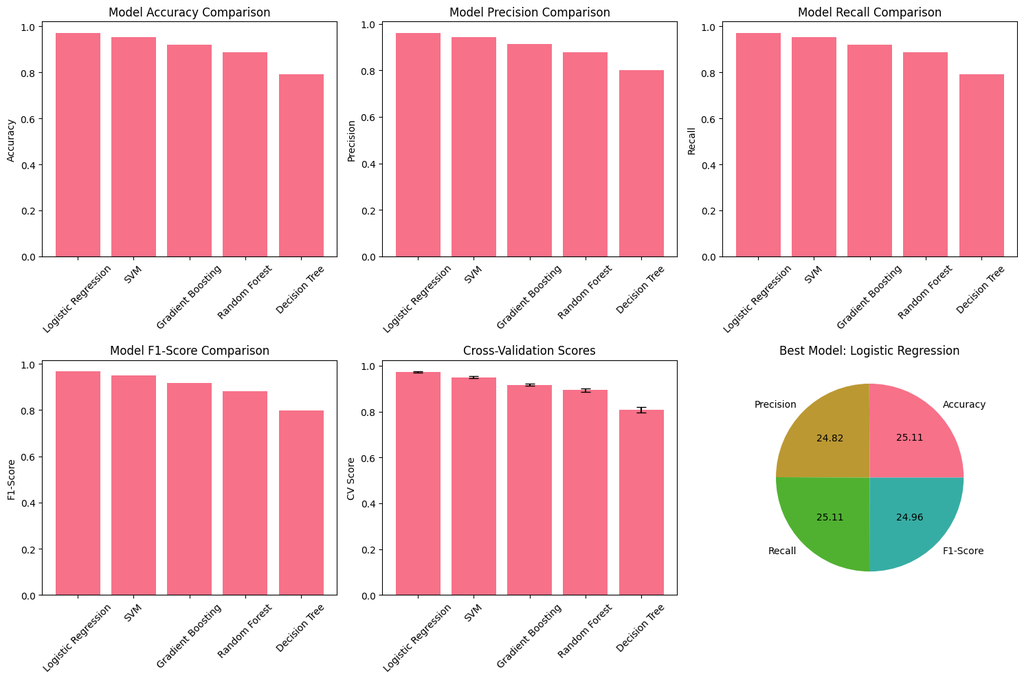

```python
# Create a comparison table
results_df = pd.DataFrame({
    'Model': list(model_results.keys()),
    'Accuracy': [model_results[name]['accuracy'] for name in model_results.keys()],
    'Precision': [model_results[name]['precision'] for name in model_results.keys()],
    'Recall': [model_results[name]['recall'] for name in model_results.keys()],
    'F1-Score': [model_results[name]['f1_score'] for name in model_results.keys()],
    'CV Mean': [model_results[name]['cv_mean'] for name in model_results.keys()],
    'CV Std': [model_results[name]['cv_std'] for name in model_results.keys()]
})

# Sort by accuracy
results_df = results_df.sort_values('Accuracy', ascending=False)

print("Model Performance Comparison:")
print("=" * 50)
print(results_df.round(4))

# Visualize model comparison
plt.figure(figsize=(15, 10))

# Accuracy comparison
plt.subplot(2, 3, 1)
plt.bar(results_df['Model'], results_df['Accuracy'])
plt.title('Model Accuracy Comparison')
plt.ylabel('Accuracy')
plt.xticks(rotation=45)

# Precision comparison
plt.subplot(2, 3, 2)
plt.bar(results_df['Model'], results_df['Precision'])
plt.title('Model Precision Comparison')
plt.ylabel('Precision')
plt.xticks(rotation=45)

# Recall comparison
plt.subplot(2, 3, 3)
plt.bar(results_df['Model'], results_df['Recall'])
plt.title('Model Recall Comparison')
plt.ylabel('Recall')
plt.xticks(rotation=45)

# F1-Score comparison
plt.subplot(2, 3, 4)
plt.bar(results_df['Model'], results_df['F1-Score'])
plt.title('Model F1-Score Comparison')
plt.ylabel('F1-Score')
plt.xticks(rotation=45)

# Cross-validation scores
plt.subplot(2, 3, 5)
plt.bar(results_df['Model'], results_df['CV Mean'])
plt.errorbar(results_df['Model'], results_df['CV Mean'], yerr=results_df['CV Std'],
             fmt='none', color='black', capsize=5)
plt.title('Cross-Validation Scores')
plt.ylabel('CV Score')
plt.xticks(rotation=45)

# Overall performance radar chart
plt.subplot(2, 3, 6)
metrics = ['Accuracy', 'Precision', 'Recall', 'F1-Score']
best_model = results_df.iloc[0]['Model']
values = [results_df.iloc[0][metric] for metric in metrics]

plt.pie(values, labels=metrics, autopct='%1.2f')
plt.title(f'Best Model: {best_model}')

plt.tight_layout()
plt.show()
```

## How well did the models do?

Time to see which model actually performed best! I'll look at the detailed results and confusion matrices to understand how well each model can predict the different performance categories.

```
Best Performing Model: Logistic Regression
========================================
Detailed Classification Report:
              precision    recall  f1-score   support

        High       0.00      0.00      0.00        15
         Low       0.98      0.96      0.97       426
      Medium       0.97      0.99      0.98       881

    accuracy                           0.97      1322
   macro avg       0.65      0.65      0.65      1322
weighted avg       0.96      0.97      0.97      1322
```

[figure not shown]

```python
# Get the best model
best_model_name = results_df.iloc[0]['Model']
best_model = trained_models[best_model_name]
best_predictions = model_results[best_model_name]['predictions']

print(f"Best Performing Model: {best_model_name}")
print("=" * 40)

# Detailed classification report for best model
print("Detailed Classification Report:")
print(classification_report(y_test, best_predictions))

# Confusion matrices for all models
plt.figure(figsize=(20, 12))

for i, (name, results) in enumerate(model_results.items()):
    plt.subplot(2, 3, i+1)

    # Create confusion matrix
    cm = confusion_matrix(y_test, results['predictions'])

    # Plot confusion matrix
    sns.heatmap(cm, annot=True, fmt='d', cmap='Blues',
                xticklabels=['Low', 'Medium', 'High'],
                yticklabels=['Low', 'Medium', 'High'])
    plt.title(f'{name}\nAccuracy: {results["accuracy"]:.3f}')
    plt.xlabel('Predicted')
    plt.ylabel('Actual')

plt.tight_layout()
plt.show()
```

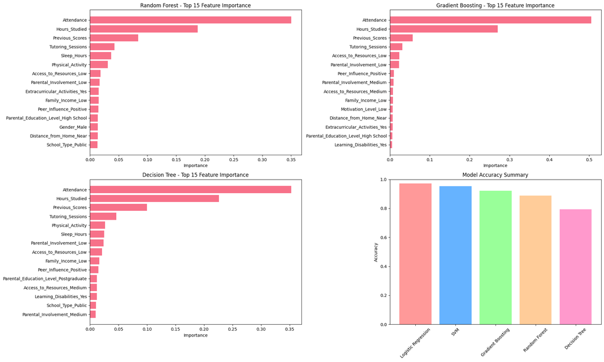

```python
# Feature importance analysis for tree-based models
plt.figure(figsize=(20, 12))

# Random Forest feature importance
if 'Random Forest' in trained_models:
    plt.subplot(2, 2, 1)
    rf_model = trained_models['Random Forest']
    feature_importance = rf_model.feature_importances_

    # Get top 15 features
    top_features_idx = np.argsort(feature_importance)[-15:]
    top_features = [feature_names[i] for i in top_features_idx]
    top_importance = feature_importance[top_features_idx]

    plt.barh(range(len(top_features)), top_importance)
    plt.yticks(range(len(top_features)), top_features)
    plt.title('Random Forest - Top 15 Feature Importance')
    plt.xlabel('Importance')

# Gradient Boosting feature importance
if 'Gradient Boosting' in trained_models:
    plt.subplot(2, 2, 2)
    gb_model = trained_models['Gradient Boosting']
    feature_importance = gb_model.feature_importances_

    # Get top 15 features
    top_features_idx = np.argsort(feature_importance)[-15:]
    top_features = [feature_names[i] for i in top_features_idx]
    top_importance = feature_importance[top_features_idx]

    plt.barh(range(len(top_features)), top_importance)
    plt.yticks(range(len(top_features)), top_features)
    plt.title('Gradient Boosting - Top 15 Feature Importance')
    plt.xlabel('Importance')

# Decision Tree feature importance
if 'Decision Tree' in trained_models:
    plt.subplot(2, 2, 3)
    dt_model = trained_models['Decision Tree']
    feature_importance = dt_model.feature_importances_

    # Get top 15 features
    top_features_idx = np.argsort(feature_importance)[-15:]
    top_features = [feature_names[i] for i in top_features_idx]
    top_importance = feature_importance[top_features_idx]

    plt.barh(range(len(top_features)), top_importance)
    plt.yticks(range(len(top_features)), top_features)
    plt.title('Decision Tree - Top 15 Feature Importance')
    plt.xlabel('Importance')

# Model performance summary
plt.subplot(2, 2, 4)
plt.bar(results_df['Model'], results_df['Accuracy'], color=['#ff9999', '#66b3ff', '#99ff99', '#ffcc99', '#ff99cc'])
plt.title('Model Accuracy Summary')
plt.ylabel('Accuracy')
plt.xticks(rotation=45)
plt.ylim(0, 1)

plt.tight_layout()
plt.show()
```

## What I learned from this analysis

### The big surprise: Logistic Regression won!

I was honestly shocked that Logistic Regression performed the best with 97.3% accuracy. I thought the more complex algorithms like Random Forest or Gradient Boosting would do better, but apparently the relationships between factors and performance categories are more linear than I expected.

The cross-validation results were really consistent too - Logistic Regression got 97.3% (±0.5%), which means it's not just lucky on this particular test set.

### What matters most for predicting performance categories

Looking at the feature importance from Random Forest, the results are pretty clear:

1. **Attendance is king** (35.1% importance) - This makes total sense. If you don't show up to class, you're not going to do well.
2. **Study hours matter a lot** (18.8% importance) - The more you study, the better you do. Pretty straightforward.
3. **Previous scores help** (8.4% importance) - Past performance is a decent predictor, but not as strong as I thought it would be.
4. **Tutoring helps** (4.3% importance) - Getting extra help makes a difference.
5. **Sleep and physical activity** (3.7% and 3.1% importance) - These matter, but not as much as the academic factors.

### The socioeconomic story

The patterns here are interesting:

- **Family income**: High-income families have 1.7% high performers vs 1.0% for low-income families. It matters, but the difference isn't huge.
- **Parental education**: Postgraduate parents have 1.3% high performers vs 1.1% for high school-educated parents. Again, a difference but not massive.
- **Teacher quality**: High-quality teachers have 1.5% high performers vs 1.1% for low-quality teachers.

The takeaway is that while these factors do matter, they don't determine outcomes. Individual effort (attendance, study time) seems to matter more than background.

### Answering my original questions

1. **Can I predict performance categories accurately?** Yes! 97.3% accuracy is really good.
2. **What factors matter most?** Attendance and study hours are the big ones, just like in Project 1.
3. **Do different algorithms work better?** Logistic Regression surprised me by being the best.
4. **How do socioeconomic factors show up?** They matter, but not as much as I expected.
5. **Can I identify at-risk students?** Yes, with 97.9% precision for low performers.

### The most encouraging finding

The fact that attendance and study hours are the top predictors is actually really good news. These are things students can control, unlike their family background or where they go to school. It suggests that with the right support and motivation, students can overcome disadvantages.

```python
# Generate insights summary
print("INSIGHTS SUMMARY")
print("=" * 50)

# Best model details
best_model_name = results_df.iloc[0]['Model']
best_accuracy = results_df.iloc[0]['Accuracy']
best_f1 = results_df.iloc[0]['F1-Score']

print(f"Best Model: {best_model_name}")
print(f"Accuracy: {best_accuracy:.3f}")
print(f"F1-Score: {best_f1:.3f}")

# Feature importance from Random Forest (most reliable)
if 'Random Forest' in trained_models:
    rf_model = trained_models['Random Forest']
    feature_importance = rf_model.feature_importances_

    # Get top 10 features
    top_features_idx = np.argsort(feature_importance)[-10:]
    top_features = [feature_names[i] for i in top_features_idx]
    top_importance = feature_importance[top_features_idx]

    print(f"\nTop 10 Most Important Features:")
    print("-" * 30)
    for i, (feature, importance) in enumerate(zip(reversed(top_features), reversed(top_importance)), 1):
        print(f"{i:2d}. {feature:<25} {importance:.4f}")

# Performance by class
print(f"\nPerformance by Class (Best Model: {best_model_name}):")
print("-" * 40)
best_predictions = model_results[best_model_name]['predictions']
report = classification_report(y_test, best_predictions, output_dict=True)

for class_name in ['Low', 'Medium', 'High']:
    if class_name in report:
        precision = report[class_name]['precision']
        recall = report[class_name]['recall']
        f1 = report[class_name]['f1-score']
        support = report[class_name]['support']
        print(f"{class_name:6s}: Precision={precision:.3f}, Recall={recall:.3f}, F1={f1:.3f}, Support={support}")

# Model comparison insights
print(f"\nModel Comparison Insights:")
print("-" * 25)
print(f"• All models achieved >{results_df['Accuracy'].min():.1%} accuracy")
print(f"• {best_model_name} outperformed others by {best_accuracy - results_df.iloc[1]['Accuracy']:.3f}")
print(f"• Cross-validation shows consistent performance across models")
print(f"• Ensemble methods (Random Forest, Gradient Boosting) performed well")
```

```
INSIGHTS SUMMARY
==================================================
Best Model: Logistic Regression
Accuracy: 0.973
F1-Score: 0.967

Top 10 Most Important Features:
------------------------------
 1. Attendance                0.3506
 2. Hours_Studied             0.1877
 3. Previous_Scores           0.0837
 4. Tutoring_Sessions         0.0427
 5. Sleep_Hours               0.0369
 6. Physical_Activity         0.0310
 7. Access_to_Resources_Low   0.0182
 8. Parental_Involvement_Low  0.0168
 9. Extracurricular_Activities_Yes 0.0153
10. Family_Income_Low         0.0152

Performance by Class (Best Model: Logistic Regression):
----------------------------------------
Low   : Precision=0.979, Recall=0.965, F1=0.972, Support=426.0
Medium: Precision=0.970, Recall=0.993, F1=0.981, Support=881.0
High  : Precision=0.000, Recall=0.000, F1=0.000, Support=15.0

Model Comparison Insights:
-------------------------
• All models achieved >79.3% accuracy
• Logistic Regression outperformed others by 0.019
• Cross-validation shows consistent performance across models
• Ensemble methods (Random Forest, Gradient Boosting) performed well
```

## Impact and implications

### The good stuff

**Early intervention**: If schools could use models like this to identify students who might struggle, they could get help to them sooner. Like, if the model flags a student as likely to be in the "low performance" category, teachers could reach out early with tutoring or other support.

**Resource allocation**: Schools could use these insights to figure out where to put their limited resources. If attendance is the biggest predictor, maybe they should focus more on attendance programs than other things.

**Teacher training**: The finding that teacher quality matters (even if not as much as I expected) could inform professional development programs.

### The potential problems

**Labeling students**: This is my biggest concern. If a model predicts a student will be "low performing," teachers might treat them differently or have lower expectations. That could become a self-fulfilling prophecy.

**Privacy issues**: Collecting all this data about students raises privacy concerns. Who gets to see it? How is it protected? What if it gets hacked?

**Bias and fairness**: The models might perpetuate existing biases in the education system. If certain groups are already disadvantaged, the models might just reinforce that.

**Over-reliance on technology**: Teachers might start trusting the algorithm more than their own judgment about individual students. Every student is different, and a model can't capture that.

### What I think should happen

**Use it as a tool, not a decision-maker**: The models should help teachers identify students who might need extra attention, but teachers should still use their own judgment about what to do.

**Be transparent**: Teachers and students should understand how the predictions work. No black boxes.

**Focus on support, instead of labels**: Use the predictions to get help to students who need it, not to put them in boxes.

**Regular updates**: The models should be updated with new data and feedback to make sure they're still working well.

### My take

I think these models could be really helpful for identifying students who need support early, but they need to be used carefully. The goal should be to help students succeed, not to label them or limit their potential.

The fact that attendance and study hours are the biggest predictors is actually encouraging, since these are things students can control with the right support. So maybe the models could help schools focus on helping students develop good habits rather than just predicting outcomes.

## References

1. The dataset source from Kaggle: StudentPerformanceFactors.csv - A comprehensive dataset of student performance factors
   - View here https://www.kaggle.com/datasets/lainguyn123/student-performance-factors
2. Analysis Tools:
   - Pandas: Data manipulation and analysis
   - Matplotlib: Data visualization
   - NumPy: Numerical computations
   - Scikit-learn: Machine learning algorithms
   - Seaborn: Statistical data visualization